# Practical Work Compilation

Franziska Günther

2020-06-18

# Linear Regression with Stan

The Coding Club Introduction to Stan made use of a dataset featuring N = 39 data points from years 1979 through 2017 during which sea ice extent was measured for the northern and southern hemisphere.

```
##   year extent_north extent_south
## 1 1979       12.328       11.700
## 2 1980       12.337       11.230
## 3 1981       12.127       11.435
## 4 1982       12.447       11.640
## 5 1983       12.332       11.389
## 6 1984       11.910       11.454
```

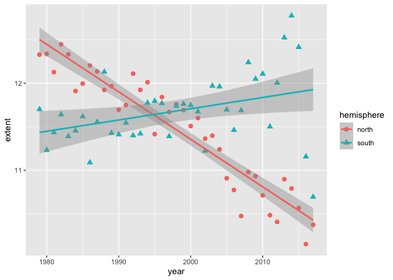

While a Bayesian Linear Model (non-informative prior) was successfully fitted to northern hemisphere sea ice data, which was found to decline over time, the tutorial invites to explore if data for the southern hemisphere shows the same development.

The scatter plot above and the below model fit diagnostics make it obvious that the univariate linear model is a worse fit for the southern hemisphere data (see particularly adjusted R-squared). The choice of model for the data is crucial since it is fed into the Stan model as the likelihood function that will be compared to the prior.

```
##
## Call:
## lm(formula = extent_south ~ yearscaled, data = seaice)
##
## Residuals:
##      Min       1Q   Median       3Q      Max
## -1.23372 -0.18142  0.01587  0.18465  0.88814
##
## Coefficients:
##              Estimate Std. Error t value Pr(>|t|)
## (Intercept) 11.421555   0.125490  91.015   <2e-16 ***
## yearscaled   0.012953   0.005468   2.369   0.0232 *
## ---
## Signif. codes:  0 '***' 0.001 '**' 0.01 '*' 0.05 '.' 0.1 ' ' 1
##
## Residual standard error: 0.3843 on 37 degrees of freedom
## Multiple R-squared:  0.1317, Adjusted R-squared:  0.1082
## F-statistic: 5.611 on 1 and 37 DF,  p-value: 0.02318
```

Predictions of the model as well as the proposed noise model don’t match data particularly well.

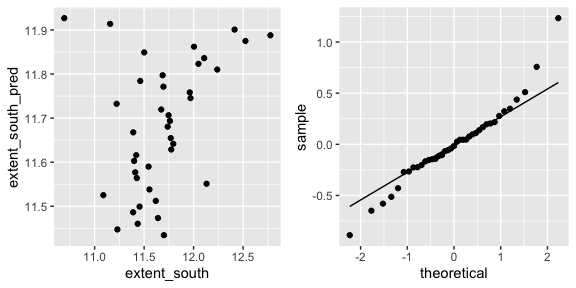

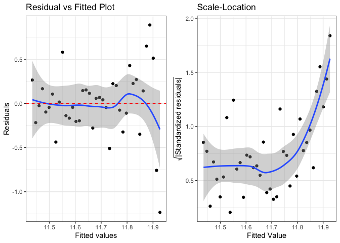

Preliminary considerations of modelling sea ice data differently included polynomial functions of the covariate (quickly discarded) and a t-distribution instead of the normal to allow for more probability density in the tails. However, linear regression under the t-distribution yielded regression coefficients very similar to the ones obtained by the one under the normal distribution.

```
## Linear model under heavy-tailed distributions
##  Data: seaice; Family: Student(df = 2.45349)
##
## Residuals:
##       Min        1Q    Median        3Q       Max
## -1.407519 -0.185150  0.009573  0.138764  0.735126
##
## Coefficients:
##              Estimate Std.Error Z value  p-value
## (Intercept)  11.3251   0.0916  123.6474   0.0000
## yearscaled    0.0199   0.0040    4.9815   0.0000
##
## Degrees of freedom: 39 total; 37 residual
## Scale estimate: 0.04983006
## Log-likelihood: -13.91098 on 3 degrees of freedom
```

Since available sample size is very small, and out of concern to overfit data with a more complicated (polynomial) model, I nevertheless decided to proceed with the linear regression model.

It has to be noted that a small sample size in the Bayesian process gives a potential prior more weight anyway and therefore makes it easy to overrun evidence of data. On the other hand, I admit to be completely naive about the development of sea ice extent in the southern hemisphere.

Set up of Stan model and data fed into it:

```r
x <- I(seaice$year - 1978)
y <- seaice$extent_south
stan_data <- list(N = N, x = x, y = y)

write("// Stan model for simple linear regression

data {
 int < lower = 1 > N; // Sample size with lower bound of 1
 vector[N] x; // Predictor
 vector[N] y; // Outcome
}

parameters {
 real alpha; // Intercept
 real beta; // Slope (regression coefficients)
 real < lower = 0 > sigma; // Error SD with lower bound 0
 real<lower=1> nu; // degrees of freedom
}

model {
 // alpha ~ normal(0.0, 10); // normal prior
 // beta ~ normal(0.0, 0.5); // normal prior
 alpha ~ exponential(0.1); // exponential prior
 beta ~ exponential(0.1); // exponential prior
 nu ~ gamma(2,0.1);
 // y ~ normal(alpha + x * beta , sigma);
 y ~ student_t(nu, alpha + x * beta, sigma);
}

generated quantities {
 real y_rep[N];

 for (n in 1:N) {
  // y_rep[n] = normal_rng(x[n] * beta + alpha, sigma);
  y_rep[n] = student_t_rng(nu, x[n] * beta + alpha, sigma);
 }
} // The posterior predictive distribution",

"stan_model1.stan")

stan_model1 <- "stan_model1.stan"

fit <- stan(file = stan_model1, data = stan_data, warmup = 500, iter = 1000, chains = 4, cores = 2, thin = 1)
```

Now, what we can do in Bayesian linear regression, but not in frequentist, since we obtained posterior distributions of our parameters alpha and beta and not only point estimates, is plotting the resulting regression lines that are possible under our posterior distributions.

```
##              mean      se_mean           sd        2.5%         25%         50%
## alpha 11.37082933 0.0038020796  0.113011794 11.14504365 11.29029548 11.37082000
## beta   0.01637157 0.0001877382  0.005670828  0.00540421  0.01239906  0.01635979
## sigma  0.31879050 0.0022706775  0.062955835  0.19671001  0.27593074  0.31952145
## nu    12.18348672 0.3494121707 11.194595279  1.93768141  4.60673167  8.10733998
##               75%       97.5%     n_eff     Rhat
## alpha 11.45078156 11.58653835  883.4971 1.005239
## beta   0.02028288  0.02723782  912.4046 1.003211
## sigma  0.35949197  0.44440936  768.7074 1.003799
## nu    16.07381505 44.50691224 1026.4569 1.001223
```

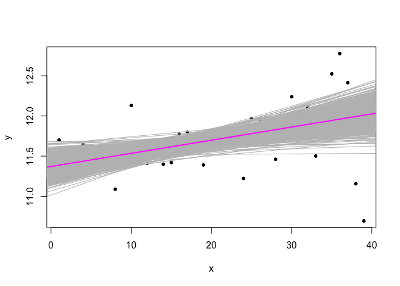

Chains seem to have converged and the effective sample size is sufficiently large (see also figure below).

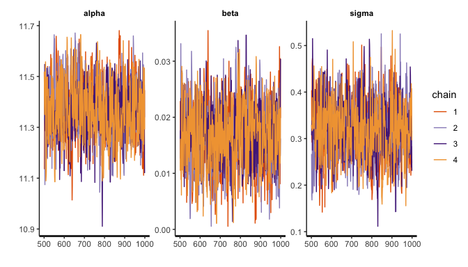

Posterior distributions of parameters: To obtain each, the other parameters have to be integrated out of the joint posterior distribution of all parameters. Mean estimate and standard error correspond to the ones obtained by the frequentist estimation.

If we would have imposed an informative conjugate prior, it would have to follow a Normal-Gamma distribution since neither mean nor variance is known to us. We would have to place a marginal prior over sigma, and a joint prior over alpha and beta, conditional on sigma.

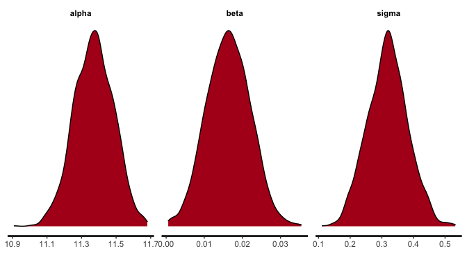

```r
# Posterior probability of beta being greater than 0
sum(posterior$beta > 0)/length(posterior$beta)
```

```
## [1] 1
```

```r
# Posterior probability of beta being greater than 0
sum(posterior$beta > 0.05)/length(posterior$beta)
```

```
## [1] 0
```

The posterior distribution of beta lies, as expected, much probability density on parameters very close to zero.

Below, densities of the first 200 iterations, that created 39 datapoints each, are plotted against the density of the original data (dark).

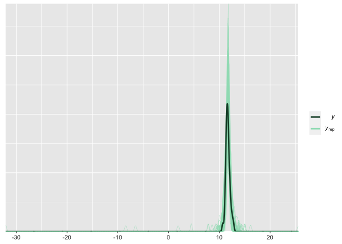

# End-of-chapter exercises (BDA3, chapter 2)

## 1

The Beta prior distribution (first factor is a constant)

$$p(\theta) = \frac{\Gamma(4+4)}{\Gamma(4)\Gamma(4)} \theta^3 (1-\theta)^3$$

is multiplied with the Binomial likelihood. For the case x < 3, three possibilities (x=2, x=1, x=0) have to be considered and added up

$$p(\theta|x<3) = {10 \choose 2} \theta^{3+2} (1-\theta)^{3+10-2} + {10 \choose 1} \theta^{3+1} (1-\theta)^{3+10-1} + {10 \choose 0} \theta^{3+0} (1-\theta)^{3+10-0}$$
Posterior probability density for $\theta$

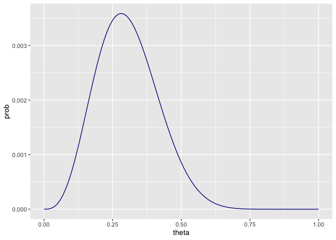

```r
theta <- seq(0,1,.01)
df_1 <- data.frame(theta = theta, prob = (45*theta^5*(1-theta)^11 + 10*theta^4*(1-theta)^12 + theta^3*(1-theta)^13))

plot_ex1 <- ggplot(df_1, aes(x=theta, y=prob)) +
  geom_line(color="darkblue")

print(plot_ex1)
```

## 3

$$p(y|\theta) \sim N(n=1000 \cdot p=\frac{1}{6}, n=1000 \cdot p=\frac{1}{6} \cdot (1-p)=\frac{5}{6})$$

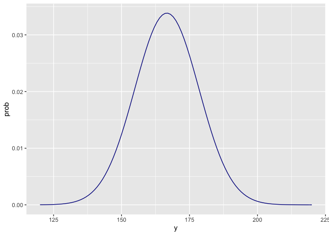

```r
y <- seq(1, 1000, 1)
mu <- 1000*(1/6)
sigma <- sqrt(1000*(1/6)*(5/6))
df_3 <- data.frame(y=y, prob=dnorm(y, mu, sigma))

plot_ex3 <- ggplot(df_3, aes(x=y, y=prob)) +
  geom_line(color="darkblue") +
  xlim(120, 220)

print(plot_ex3)
```

```r
# 5% of density lies left of the following number of 6's
qnorm(0.05, mu, sigma)
```

```
## [1] 147.2819
```

## 4

y: number of 6’s in 1000 throws of a (possibly) unfair die

$\theta_i$: probability that die lands 6 in those 1000 throws

prior for $\theta$

$$p(\theta_1 = \frac{1}{12}) = 0.25 \\
p(\theta_2 = \frac{1}{6}) = 0.5 \\
p(\theta_3 = \frac{1}{4}) = 0.25 \\$$
prior predictive distribution

$$\sum_{i=1}^{3} p(\theta_i) p(y|\theta_i) \\
p(y|\theta_1) \sim N(\frac{1}{12} \cdot 1000, 1000 \cdot \frac{1}{12} \cdot \frac{11}{12}) \\
p(y|\theta_2) \sim N(\frac{1}{6} \cdot 1000, 1000 \cdot \frac{1}{6} \cdot \frac{5}{6}) \\
p(y|\theta_2) \sim N(\frac{1}{4} \cdot 1000, 1000 \cdot \frac{1}{4} \cdot \frac{3}{4}) \\$$

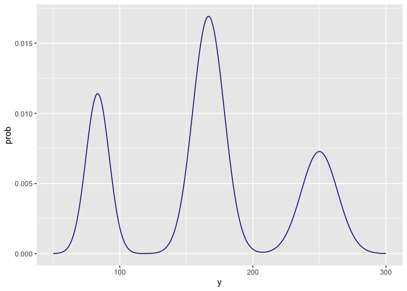

```r
y <- seq(1,1000, 1)
df_4 <- data.frame(y = y, prob = (0.25*dnorm(y, 1000/12, sqrt(1000*1/12*11/12)) + 0.5*dnorm(y, 1000/6, sqrt(1000*1/6*5/6)) + 0.25*dnorm(y, 1000/4, sqrt(1000*1/4*3/4))))

plot_ex4 <- ggplot(df_4, aes(x=y, y=prob)) +
  geom_line(color="darkblue") +
  xlim(50, 300)

print(plot_ex4)
```